# Dark Rockfish

*Sebastes ciliatus*

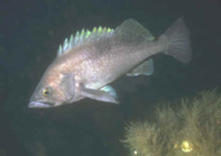

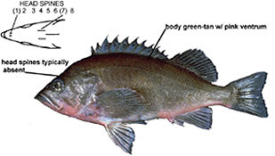

**Body color:** Gray to greenish brown on back and sides, darker blotches under soft dorsal fin; ventral sides and pectoral and pelvic fins tinged w/ pink; orange-red-brown flecks on sides. (Also see above underwater photo.)

**Peritoneum color:** light to dark **Shape between eyes:** convex

**Counts:** D:XIII,13-16, Ar:7-9, P1:17-19, GR:32-36, LLp:45-52, LLs:47-58, V:28

**Occurence:** Bering Sea - British Columbia

**Depth:** 525 meters **Size:** 53 cm **Species code:** 30151

**Similar species:**

- *Dark Dusky rockfish* - mouth smaller, maxilla to midorbit, symphyseal knob small; peritoneum jet black; body uniform black or dark blue
- *Black rockfish* - anal-fin margin rounded w/ anterior slant; peritoneum light; spinous dorsal fin often w/ black spots; mandibular pores reduced (evident in Dusky RF); head spine count differs, spine 4 present
- *Yellowtail rockfish* - peritoneum light; head spine count differs; body w/ brassy wash; fins dusky yellow;dorsal rays typically 14 (typically 15 in Dusky RF)
- *Northern rockfish* - typically 14 dorsal spines (typically 13 in Dusky RF); oblique light band on lower portion of pectoral fin (faint in Dusky RF)
- *Widow rockfish* - anal-fin margin w/ strong posterior slant; head spine count differs; maxilla extends anterior to midorbit (maxilla extends to beyond midorbit in Dusky RF)

Back to Group

**Corrections:** If you see mistakes or want to suggest changes, please create an [issue](https://github.com/zoyafuso-NOAA/RACE_Survey_App/issues) on the source repository or

*reach out to Liz Dawson (Liz.Dawson AT noaa.gov).*